```python
import numpy as np
import pandas as pd

import matplotlib.pyplot as plt
import seaborn as sns

import statsmodels.api as sm
from statsmodels.stats.outliers_influence import variance_inflation_factor

from sklearn.preprocessing import PolynomialFeatures
from sklearn.linear_model import LinearRegression, Ridge, Lasso
from sklearn.metrics import mean_squared_error, r2_score
from sklearn.model_selection import train_test_split, cross_val_score

from scipy.stats import skew, kurtosis, iqr
from scipy import stats


plt.style.use('seaborn-v0_8-darkgrid')
sns.set_palette("husl")

# Display settings
pd.set_option('display.max_columns', None)
pd.set_option('display.width', None)

print("All libraries loaded successfully!")
print(f"NumPy version: {np.__version__}")
print(f"Pandas version: {pd.__version__}")
print(f"Matplotlib version: {plt.matplotlib.__version__}")
print(f"Seaborn version: {sns.__version__}")
print(f"Statsmodels version: {sm.__version__}")
```

```
All libraries loaded successfully!
NumPy version: 2.3.5
Pandas version: 2.3.3
Matplotlib version: 3.10.6
Seaborn version: 0.13.2
Statsmodels version: 0.14.5
```

# Best-Practices Handbook

## Volatility Modeling

**Author:** FRANSISCA MUZVAZVI

**Date:** May 3, 2026

### 📋 Handbook Contents

1. Multicollinearity
2. Skewness
3. Sensitivity to Outlier
4. Overfitting

MULTICOLLINEARITY

```python
from IPython.display import display, Markdown

definition = r"""
### Multicollinearity

It is quantified by the *Variance Inflation Factor (VIF)* for predictor \( j \):

$$
\text{VIF}_j = \frac{1}{1 - R_j^2}
$$

where \( R_j^2 \) is the coefficient of determination from regressing predictor \( j \) against all other predictors. A VIF > 5–10 indicates problematic multicollinearity.

*Description:* Multicollinearity occurs when two or more explanatory variables are highly linearly correlated, causing unstable coefficient estimates and inflated standard errors..
"""

display(Markdown(definition))
```

Multicollinearity

It is quantified by the *Variance Inflation Factor (VIF)* for predictor ( j ):

$$ \text{VIF}_j = \frac{1}{1 - R_j^2} $$

where ( R_j^2 ) is the coefficient of determination from regressing predictor ( j ) against all other predictors. A VIF > 5–10 indicates problematic multicollinearity.

*Description:* Multicollinearity occurs when two or more explanatory variables are highly linearly correlated, causing unstable coefficient estimates and inflated standard errors..

```python
np.random.seed(42)
n = 200


inflation = np.random.normal(50, 15, n)
parallel_premium = 0.85 * inflation + np.random.normal(5, 5, n)
reserves_depletion = 0.80 * inflation + np.random.normal(2, 6, n)
volatility = 0.5 * inflation + np.random.normal(10, 8, n)


data = pd.DataFrame({
    'inflation': inflation,
    'parallel_premium': parallel_premium,
    'reserves_depletion': reserves_depletion,
    'volatility': volatility
})


X = sm.add_constant(data[['inflation', 'parallel_premium', 'reserves_depletion']])
vif = pd.DataFrame()
vif['Variable'] = X.columns
vif['VIF'] = [variance_inflation_factor(X.values, i) for i in range(X.shape[1])]

print("=== Multicollinearity in Zimbabwe Market Data ===")
print(vif.round(2))
print("\nCorrelation Matrix:")
print(data[['inflation', 'parallel_premium', 'reserves_depletion']].corr().round(3))


if (vif['VIF'][1:] > 5).any():
    print("\n⚠️ Multicollinearity detected: VIF > 5 for some variables")
```

```
=== Multicollinearity in Zimbabwe Market Data ===
             Variable    VIF
0               const  14.72
1           inflation  10.57
2    parallel_premium   7.31
3  reserves_depletion   4.08

Correlation Matrix:
                    inflation  parallel_premium  reserves_depletion
inflation               1.000             0.929               0.869
parallel_premium        0.929             1.000               0.804
reserves_depletion      0.869             0.804               1.000

⚠️ Multicollinearity detected: VIF > 5 for some variables
```

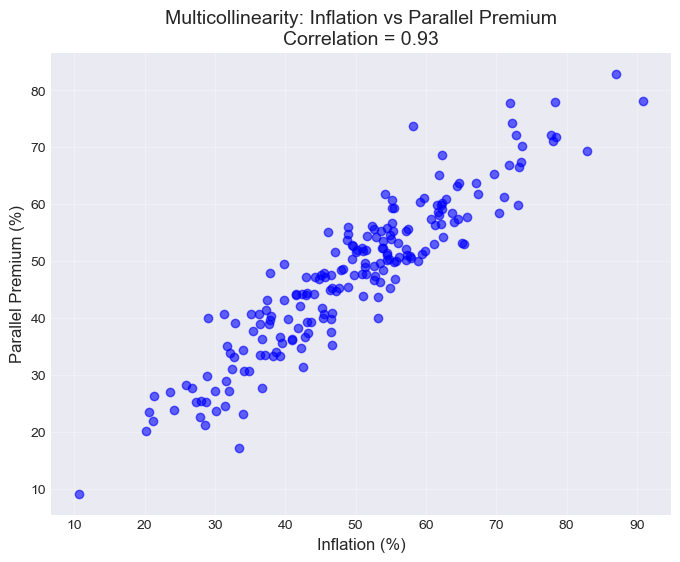

```python
np.random.seed(42)
n = 200
inflation = np.random.normal(50, 15, n)
parallel_premium = 0.85 * inflation + np.random.normal(5, 5, n)

data = pd.DataFrame({
    'inflation': inflation,
    'parallel_premium': parallel_premium
})


corr = data['inflation'].corr(data['parallel_premium'])


plt.figure(figsize=(8, 6))
plt.scatter(data['inflation'], data['parallel_premium'], alpha=0.6, color='blue')
plt.xlabel('Inflation (%)', fontsize=12)
plt.ylabel('Parallel Premium (%)', fontsize=12)
plt.title(f'Multicollinearity: Inflation vs Parallel Premium\nCorrelation = {corr:.2f}', fontsize=14)
plt.grid(True, alpha=0.3)
plt.show()
```

```python
np.random.seed(42)
n = 200
inflation = np.random.normal(50, 15, n)
parallel_premium = 0.85 * inflation + np.random.normal(5, 5, n)
reserves_depletion = 0.80 * inflation + np.random.normal(2, 6, n)
volatility = 0.5 * inflation + np.random.normal(10, 8, n)

data = pd.DataFrame({
    'inflation': inflation,
    'parallel_premium': parallel_premium,
    'reserves_depletion': reserves_depletion,
    'volatility': volatility
})

print("=" * 50)
print("DIAGNOSIS: Multicollinearity Test")
print("=" * 50)


print("\n1. Correlation Matrix:")
print(data[['inflation', 'parallel_premium', 'reserves_depletion']].corr().round(3))


X = sm.add_constant(data[['inflation', 'parallel_premium', 'reserves_depletion']])
print("\n2. VIF (Variance Inflation Factor):")
for i in range(1, len(X.columns)):
    vif = variance_inflation_factor(X.values, i)
    print(f"   {X.columns[i]}: VIF = {vif:.2f}")


print("\n" + "=" * 50)
print("FINAL DIAGNOSIS:")
print("=" * 50)

high_corr = False
for col1 in ['inflation', 'parallel_premium', 'reserves_depletion']:
    for col2 in ['inflation', 'parallel_premium', 'reserves_depletion']:
        if col1 != col2:
            if abs(data[col1].corr(data[col2])) > 0.7:
                high_corr = True

vif_values = [variance_inflation_factor(X.values, i) for i in range(1, len(X.columns))]
high_vif = any(v > 5 for v in vif_values)

if high_vif:
    print("⚠️  Multicollinearity EXISTS (VIF > 5)")
    if any(v > 10 for v in vif_values):
        print("🚨 SEVERE multicollinearity detected (VIF > 10)")
else:
    print("✅ No significant multicollinearity detected")
```

```
==================================================
DIAGNOSIS: Multicollinearity Test
==================================================

1. Correlation Matrix:
                    inflation  parallel_premium  reserves_depletion
inflation               1.000             0.929               0.869
parallel_premium        0.929             1.000               0.804
reserves_depletion      0.869             0.804               1.000

2. VIF (Variance Inflation Factor):
   inflation: VIF = 10.57
   parallel_premium: VIF = 7.31
   reserves_depletion: VIF = 4.08

==================================================
FINAL DIAGNOSIS:
==================================================
⚠️  Multicollinearity EXISTS (VIF > 5)
🚨 SEVERE multicollinearity detected (VIF > 10)
```

Here is the **shortened** Damage section:

## Damage: Multicollinearity

Multicollinearity among **inflation**, **parallel_premium**, and **reserves_depletion** in our Zimbabwe volatility model causes:

1. **Unstable coefficients** – Small data changes produce wildly different estimates
2. **Inflated standard errors** – Important variables appear statistically insignificant
3. **Misleading factor importance** – Cannot identify which variable truly drives volatility
4. **Poor forecasting** – Model works in-sample but fails out-of-sample